# Dynamic Lot Sizing: When the Demand Rate Changes

Manuel D. Rossetti, PhD P.E.

## Agenda

- An item with a season, and why the economic order quantity has nothing to say about it
- The requirements schedule, and what a plan costs
- Three plans without any theory, costed by hand
- Two properties that make the problem small: zero-inventory ordering and the window cost
- The problem as a shortest path, and the Wagner-Whitin recursion worked by hand
- The same problem as a mixed integer program

## An Item With a Season

A distributor of turf-equipment parts stocks a mower deck belt. It sells almost nowhere in winter, very heavily in spring, and again in autumn as dealers build up for the next season.

| $t$ | 1 | 2 | 3 | 4 | 5 | 6 | 7 | 8 | 9 | 10 | 11 | 12 |
| --- | --- | --- | --- | --- | --- | --- | --- | --- | --- | --- | --- | --- |
| $d_t$ | 40 | 60 | 120 | 300 | 420 | 260 | 120 | 40 | 0 | 80 | 180 | 220 |

| Question | Answer |
| --- | --- |
| *What is stocked?* | One item, the belt |
| *What is the demand process?* | Known in advance, but different in every month |
| *When is inventory reviewed?* | Once a month, at the month boundary |
| *What triggers replenishment, and how much?* | A plan decided before the year starts |
| *What happens to unmet demand?* | None occurs; every requirement is met in its month |
| *What costs are incurred, and when?* | $k = \$300$ each month an order is placed; $h$ for every belt carried into the next month |

## The Economic Order Quantity Has Nothing to Say

Recall that $h = ic$. Then nothing stops us from applying the economic order quantity to the average requirement:

$$\begin{aligned}
h &= ic = 0.02 \times \$50 = \$1.00 \text{ per belt per month}
&&\text{the holding rate}\\
\bar{d} &= 1{,}840 / 12 = 153.33 \text{ belts per month}
&&\text{the average requirement}\\
Q^{*} &= \sqrt{\frac{2(300)(153.33)}{1.00}} = 303.3 \text{ belts}
&&\text{the economic order quantity}\\
Q^{*}/\bar{d} &= 303.3 / 153.33 = 1.98 \text{ months}
&&\text{its time supply}
\end{aligned}$$

Two months of supply is five months of stock in February and less than one month in May. The quantity was derived from a sawtooth of identical triangles, and this item never has one.

The classical argument minimizes cost per unit time over **one cycle**, and it can because every cycle is the same. Here there is no repeating cycle, so there is nothing for the calculus to minimize. We are no longer looking for a quantity. We are looking for a **schedule**.

## The Requirements Schedule

The horizon runs over $N$ periods, $t = 1, \ldots, N$. In each period let

- $d_t$ represent the **requirement** in period $t$,
- $k_t$ the cost of placing an order in period $t$,
- $c_t$ the unit purchase cost in period $t$, and
- $h_t$ the cost of carrying one unit from the end of period $t$ into $t+1$.

Together these are the **requirements schedule**. In every example $k_t = k$, $c_t = c$ and $h_t = h$, and the subscript is dropped when that is so.

Let $d[t,u]$ represent the requirement of periods $t$ through $u$:

$$d[t,u] = \sum_{s=t}^{u} d_s, \qquad d[t,u] = 0 \text{ when } u < t .$$

For example, $d[1,3] = 40 + 60 + 120 = 220$, and $d[5,9] = 420 + 260 + 120 + 40 + 0 = 840$.

## The Assumptions That Matter

Ten assumptions place the model. Four of them shape every number today.

**Demand within a period is met from stock at its start (4).** A unit that arrives in period $t$ and is consumed in period $t$ is never held, so it is charged nothing.

**No shortages (6).** Every requirement is met in the period it falls.

**Start and end empty (8).** The plan neither inherits nor bequeaths a position, so the cost computed is the cost of the horizon.

**Carrying is charged on the ending balance (10).** Some treatments charge the average of the beginning and ending balances, and get a different answer to the same problem.

Assumption 2, that the requirements are **known** for all $N$ periods, is the strong one. Next session is about what to do because it is false.

## What a Plan Costs

A plan is a quantity $Q_t \ge 0$ for each period. Let $I_t$ represent the ending inventory, and $y_t = 1$ if an order is placed in period $t$ and 0 otherwise:

$$\begin{aligned}
I_t &= I_{t-1} + Q_t - d_t, \qquad I_0 = I_N = 0, \quad I_t \ge 0
&&\text{the balance, with no shortages}\\
TC &= \sum_{t} k_t y_t + \sum_{t} c_t Q_t + \sum_{t} h_t I_t
&&\text{ordering, purchase, carrying}\\
\text{purchase} &= c \sum_{t} Q_t = c \sum_{t} d_t
&&\text{constant $c$; assumptions 6 and 8 force } \textstyle\sum Q_t = \sum d_t\\
TRC &= \sum_{t} k_t y_t + \sum_{t} h_t I_t
&&\text{drop the constant: the relevant cost}
\end{aligned}$$

Every figure today is a relevant cost unless it says otherwise.

If the belt costs $50 through June and $54 afterwards, buying in June for a July requirement is worth $4 a belt, and the purchase term becomes part of the decision. This is the one place in the book where it cannot be dropped, and the derivations keep $c_t$ for that case.

## Three Plans Without Any Theory

**Lot-for-lot** orders what each period needs, $Q_t = d_t$. Nothing is ever carried. It is the plan an MRP system produces by default.

**An adjusted economic order quantity** computes $Q^{*} = 303.3$ from the average, then covers the whole number of periods whose total comes closest to $Q^{*}$. It keeps the quantity roughly steady and lets the timing float.

**A periodic order quantity** converts $Q^{*}$ into a time supply, $T_{EOQ} = Q^{*}/\bar{d} = 1.98$, rounds it to $T = 2$ months, and orders two months of requirement every time: in months 1, 3, 5, 7, 9 and 11.

The *adjustment* matters. A stricter rule that orders exactly $Q^{*}$ every time cannot promise to finish the horizon empty, so it breaks assumption 8 and does not fit this model.

## Costing the Periodic Plan by Hand

Let’s take $T = 2$. The order in month 1 covers months 1 and 2, so $Q_1 = 40 + 60 = 100$.

| $t$ | $d_t$ | $I_{t-1}$ | $Q_t$ | $I_t = I_{t-1} + Q_t - d_t$ | Setup | Carrying |
| --- | --- | --- | --- | --- | --- | --- |
| 1 | 40 | 0 | 100 | 60 | $300 | $60 |
| 2 | 60 | 60 | 0 | 0 |  | $0 |
| 3 | 120 | 0 | 420 | 300 | $300 | $300 |
| 4 | 300 | 300 | 0 | 0 |  | $0 |
| 5 | 420 | 0 | 680 | 260 | $300 | $260 |
| 6 | 260 | 260 | 0 | 0 |  | $0 |
| 7 | 120 | 0 | 160 | 40 | $300 | $40 |
| 8 | 40 | 40 | 0 | 0 |  | $0 |
| 9 | 0 | 0 | 80 | 80 | $300 | $80 |
| 10 | 80 | 80 | 0 | 0 |  | $0 |
| 11 | 180 | 0 | 400 | 220 | $300 | $220 |
| 12 | 220 | 220 | 0 | 0 |  | $0 |

Six orders cost $1,800, and 960 belt-months at $1.00 cost $960: **$2,760**. *The check:* $\sum Q_t = 1{,}840 = \sum d_t$, and the year ends empty.

## The Adjusted Plan, Worked

At each order, compare the running totals with $Q^{*} = 303.3$ and stop at the closest.

| Order in | Running totals | Closest | Covers | Belt-months carried |
| --- | --- | --- | --- | --- |
| 1 | 40, 100, **220**, 520 | 220 | 1 to 3 | $180 + 120 = 300$ |
| 4 | **300**, 720 | 300 | 4 | 0 |
| 5 | **420**, 680 | 420 | 5 | 0 |
| 6 | **260**, 380 | 260 | 6 | 0 |
| 7 | 120, 160, 160, **240**, 420 | 240 | 7 to 10 | $120 + 80 + 80 = 280$ |
| 11 | 180, **400** | 400 | 11 to 12 | 220 |

Six orders cost $1,800 and 800 belt-months cost $800: **$2,600**.

| Plan | Orders | Setup | Carrying | Relevant cost |
| --- | --- | --- | --- | --- |
| Lot-for-lot | 11 | $3,300 | $0 | $3,300 |
| Adjusted economic order quantity | 6 | $1,800 | $800 | $2,600 |
| Periodic order quantity, $T = 2$ | 6 | $1,800 | $960 | $2,760 |

## Zero-Inventory Ordering

**An optimal plan never orders in a period that starts with stock on hand:** $I_{t-1} Q_t = 0$ for every $t$.

The argument is an exchange. Suppose a plan orders $Q_t > 0$ into $I_{t-1} > 0$. Let $\delta = \min(I_{t-1}, Q_t) > 0$; those units were bought in some earlier period $r < t$. Buy them in $t$ instead:

$$\begin{aligned}
\text{feasibility} &: \text{unchanged}
&&\text{the same units in the same periods}\\
\text{setup in } t &: \text{unchanged}
&&\text{period $t$ still orders}\\
\text{carrying} &: -\,\delta \textstyle\sum_{s=r}^{t-1} h_s \le 0
&&\text{the $\delta$ units no longer wait from $r$ to $t$}\\
\text{purchase} &: \delta\,(c_t - c_r) = 0
&&\text{constant unit cost}
\end{aligned}$$

Thus, the new plan costs no more, and if it empties period $r$ a setup is saved as well. Repeating the exchange removes every violation.

## What That Buys

If a plan orders only when empty, an order in period $t$ must cover periods $t$ through the period before the next order, and no more. That is, **the quantity is determined by the timing**:

$$Q_t = d[t,u] \quad \text{where $u + 1$ is the next period with an order.}$$

Thus, a plan **is** a set of order periods. Period 1 always orders, because inventory starts at zero, and each of periods 2 through $N$ either orders or does not:

$$2^{N-1} = 2^{11} = 2{,}048 \text{ plans for the belt}, \qquad 2^{51} \approx 2 \times 10^{15} \text{ at } N = 52 .$$

Enumeration is not the answer. The fact that the plans can be **counted** at all is what makes the rest of the chapter possible.

## The Window Cost

Let the **window cost** $w(t,u)$ represent the cost of a replenishment placed in period $t$ that covers periods $t$ through $u$. The units for period $t$ are never carried; those for $t+1$ are charged $h_t$; those for $t+2$ are charged $h_t + h_{t+1}$; and so on:

$$\begin{aligned}
w(t,u) &= k_t + \sum_{s=t}^{u} d_s \left( c_t + \sum_{r=t}^{s-1} h_r \right)
&&\text{order, buy, and carry each unit until used}\\
\hat{c}(t,s) &= c_t + \sum_{r=t}^{s-1} h_r, \qquad \hat{c}(t,t) = c_t
&&\text{one unit bought in $t$, used in $s$}\\
w(t,u) &= k_t + \sum_{s=t}^{u} d_s\, \hat{c}(t,s)
&&\text{an inner product of requirements and prices}\\
w(t,u) &= k + h \sum_{s=t}^{u} (s - t)\, d_s
&&\text{constant costs, purchase term dropped}
\end{aligned}$$

Notice two things. $w(t,u)$ depends on **no decision**, so every window cost can be computed once, before any search. And it increases in $u$ with growing steps, because a unit added at the far end has waited longest.

## The Window Costs of the First Half Year

With $k = \$300$ and $h = \$1.00$: $w(1,3) = 300 + 1.00\left[0(40) + 1(60) + 2(120)\right] = 300 + 300 = \$600$, and a window that starts later counts the wait from its own first month: $w(2,4) = 300 + 1.00\left[0(60) + 1(120) + 2(300)\right] = \$1{,}020$.

| $w(t,u)$ | $u = 1$ | 2 | 3 | 4 | 5 | 6 |
| --- | --- | --- | --- | --- | --- | --- |
| $t = 1$ | 300 | 360 | 600 | 1,500 | 3,180 | 4,480 |
| 2 |  | 300 | 420 | 1,020 | 2,280 | 3,320 |
| 3 |  |  | 300 | 600 | 1,440 | 2,220 |
| 4 |  |  |  | 300 | 720 | 1,240 |
| 5 |  |  |  |  | 300 | 560 |
| 6 |  |  |  |  |  | 300 |

Every diagonal entry is $300: one period carries nothing. Each step along a row is $h(u + 1 - t)\,d_{u+1}$. Along row 1 that is $1(60)$, $2(120)$, $3(300)$, $4(420)$, $5(260)$, or 60, 240, 900, 1,680 and 1,300, growing until month 6, whose requirement is smaller than month 5’s.

## A Requirement That Forces an Order

Suppose $d_t > k_t / h_{t-1}$. Then

$$\begin{aligned}
h_{t-1}\, d_t &> k_t
&&\text{multiply through by } h_{t-1}\\
\text{carry $d_t$ in from $t-1$} &> \text{order afresh in $t$}
&&\text{read each side as a cost}
\end{aligned}$$

Thus, no optimal plan carries anything into period $t$, and every optimal plan orders in period $t$.

For the belt, $k/h = 300/1.00 = 300$ belt-months. Month 5 needs 420 belts, and $420 > 300$, so **every optimal plan orders in month 5**. Nothing else in the year is that large.

A forced order **splits the horizon**. No window spans months 4 and 5, so one problem of 12 periods becomes two, of 4 and 8. Next session shows this is also why a rolling horizon can be cut short without losing anything.

## The Problem Is a Shortest Path

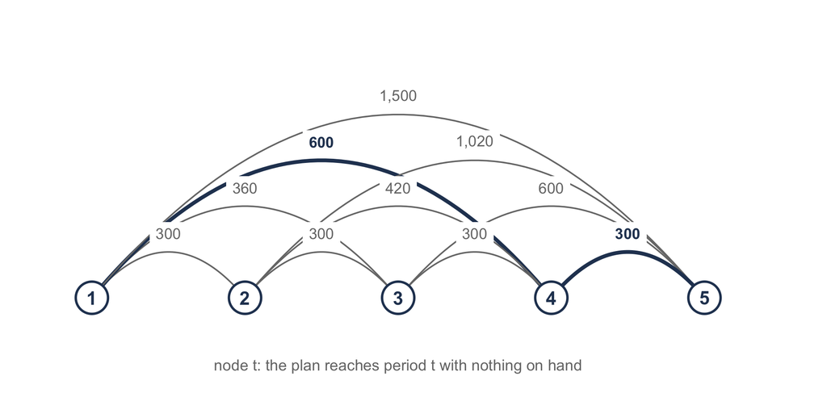

Node $t$ means the plan reaches period $t$ holding nothing. The arc from $t$ to $u + 1$ is a replenishment in $t$ covering through $u$, priced $w(t,u)$.

A path from node 1 to node $N + 1$ is a sequence of windows that tile the horizon, which is a plan, and its length is the plan’s cost.

Notice the heavy path for the first four months: order in month 1 to cover months 1 to 3, and again in month 4, for $600 + 300 = \$900$.

Thus, lot sizing is a shortest path on an acyclic network of $N + 1$ nodes and $N(N+1)/2$ arcs, every arc priced before the search begins.

## The Recursion

Let $V(u)$ represent the least cost of covering periods 1 through $u$ and arriving at $u + 1$ with nothing on hand, and $S(u)$ the period in which that plan’s last order is placed. Then $V(0) = 0$ and

$$V(u) = \min_{1 \le t \le u} \left\{ V(t-1) + w(t,u) \right\}, \qquad u = 1, \ldots, N .$$

Read it as a question about the **last order**. Whatever the best plan for periods 1 through $u$ is, its last order falls in some period $t$ and covers $t$ through $u$. Everything before $t$ is a plan for periods 1 through $t - 1$ that arrives at $t$ empty, and it had better be the cheapest such plan, or we could substitute the cheapest and do better.

$V(N)$ is the optimal cost. The **traceback** recovers the plan: the last order starts in $S(N)$; the one before it starts in $S(S(N) - 1)$; and so on until an order starts in period 1.

## The Algorithm

```
wagnerWhitin(d, k, c, h over periods 1..N):

    // the windows, which depend on no decision
    for t = 1 to N:
        for u = t to N:
            w(t,u) <- k(t) + sum over s in t..u of d(s) * chat(t,s)

    // the recursion
    V(0) <- 0
    for u = 1 to N:
        V(u) <- infinity
        for t = 1 to u:
            if V(t-1) + w(t,u) < V(u):
                V(u) <- V(t-1) + w(t,u)
                S(u) <- t

    // the traceback
    u <- N
    while u >= 1:
        t <- S(u)
        add (order in period t, quantity d[t,u]) to orders
        u <- t - 1
```

Notice that the three blocks are independent: the windows are data, the recursion is a shortest path, and the traceback reads the plan off the pointers.

## The Recursion on the First Half Year

Each entry is $V(t-1)$ from an earlier column plus a window cost. One column per click; the least entry in each column is $V(u)$.

| $V(t-1) + w(t,u)$ | $u = 1$ | 2 | 3 | 4 | 5 | 6 |
| --- | --- | --- | --- | --- | --- | --- |
| last order in 1 | **300** | **360** | **600** | 1,500 | 3,180 | 4,480 |
| 2 |  | 600 | 720 | 1,320 | 2,580 | 3,620 |
| 3 |  |  | 660 | 960 | 1,800 | 2,580 |
| 4 |  |  |  | **900** | 1,320 | 1,840 |
| 5 |  |  |  |  | **1,200** | **1,460** |
| 6 |  |  |  |  |  | 1,500 |
| **$V(u)$** | 300 | 360 | 600 | 900 | 1,200 | 1,460 |
| **$S(u)$** | 1 | 1 | 1 | 4 | 5 | 5 |

## Column 4, Entry by Entry

Covering periods 1 through 4, the last order falls in one of four periods:

$$\begin{aligned}
t = 1 &: V(0) + w(1,4) = 0 + 1{,}500 = 1{,}500
&&\text{one order covers all four}\\
t = 2 &: V(1) + w(2,4) = 300 + 1{,}020 = 1{,}320
&&\text{best plan for month 1, then 2 to 4}\\
t = 3 &: V(2) + w(3,4) = 360 + 600 = 960
&&\text{best plan for 1 to 2, then 3 to 4}\\
t = 4 &: V(3) + w(4,4) = 600 + 300 = 900
&&\text{best plan for 1 to 3, then 4 alone}
\end{aligned}$$

The least is 900, so $V(4) = 900$ and $S(4) = 4$.

Notice that each line reuses a $V$ already computed. Nothing is ever recomputed, and that is why the whole table is $N(N+1)/2$ additions and minima: 21 for six months, 78 for twelve, 1,378 for a 52-week horizon.

## The Traceback, and the Check

The traceback starts at $u = 6$:

$$\begin{aligned}
S(6) = 5 &: \text{order in 5 covers 5 to 6}, \; d[5,6] = 420 + 260 = 680
&&\text{now } u = 4\\
S(4) = 4 &: \text{order in 4 covers 4 alone}, \; d[4,4] = 300
&&\text{now } u = 3\\
S(3) = 1 &: \text{order in 1 covers 1 to 3}, \; d[1,3] = 220
&&\text{period 1 reached: stop}
\end{aligned}$$

| $t$ | 1 | 2 | 3 | 4 | 5 | 6 |
| --- | --- | --- | --- | --- | --- | --- |
| $d_t$ | 40 | 60 | 120 | 300 | 420 | 260 |
| $Q_t$ | 220 | 0 | 0 | 300 | 680 | 0 |
| $I_t$ | 180 | 120 | 0 | 0 | 260 | 0 |

*The check.* Three orders cost $900 and $180 + 120 + 260 = 560$ belt-months cost $560, for $1,460 $= V(6)$. The recursion and the ledger are two readings of the same numbers. That check is worth performing every time, because if the ledger does not reproduce $V(N)$ then one of them was done wrong.

## Column 7 of the Full Year

The first six columns do not change, since $V(u)$ depends only on the months through $u$. Month 7 requires 120 belts, so each row of the window table is extended by one step: $w(t,7) = w(t,6) + 1.00(7 - t)(120)$.

| Last order in $t$ | $V(t-1)$ | $w(t,6)$ | Step, $(7-t)(120)$ | $w(t,7)$ | $V(t-1) + w(t,7)$ |
| --- | --- | --- | --- | --- | --- |
| 1 | 0 | 4,480 | 720 | 5,200 | 5,200 |
| 2 | 300 | 3,320 | 600 | 3,920 | 4,220 |
| 3 | 360 | 2,220 | 480 | 2,700 | 3,060 |
| 4 | 600 | 1,240 | 360 | 1,600 | 2,200 |
| 5 | 900 | 560 | 240 | 800 | 1,700 |
| 6 | 1,200 | 300 | 120 | 420 | **1,620** |
| 7 | 1,460 |  |  | 300 | 1,760 |

The least is 1,620, so $V(7) = 1{,}620$ and $S(7) = 6$: cover the first five months as cheaply as possible, for $1,200, then order in month 6 for months 6 and 7. Columns 8 through 12 repeat the computation, each with one more candidate.

## The Full Twelve Months

| $u$ | 1 | 2 | 3 | 4 | 5 | 6 | 7 | 8 | 9 | 10 | 11 | 12 |
| --- | --- | --- | --- | --- | --- | --- | --- | --- | --- | --- | --- | --- |
| $V(u)$ | 300 | 360 | 600 | 900 | 1,200 | 1,460 | 1,620 | 1,700 | 1,700 | 2,000 | 2,180 | 2,480 |
| $S(u)$ | 1 | 1 | 1 | 4 | 5 | 5 | 6 | 6 | 6 | 10 | 10 | 12 |

Tracing back from $u = 12$: $S(12) = 12$, $S(11) = 10$, $S(9) = 6$, $S(5) = 5$, $S(4) = 4$, $S(3) = 1$. Orders in months 1, 4, 5, 6, 10 and 12:

| $t$ | 1 | 2 | 3 | 4 | 5 | 6 | 7 | 8 | 9 | 10 | 11 | 12 |
| --- | --- | --- | --- | --- | --- | --- | --- | --- | --- | --- | --- | --- |
| $Q_t$ | 220 | 0 | 0 | 300 | 420 | 420 | 0 | 0 | 0 | 260 | 0 | 220 |
| $I_t$ | 180 | 120 | 0 | 0 | 0 | 160 | 40 | 0 | 0 | 180 | 0 | 0 |

*The check.* Six orders cost $1,800, and $180 + 120 + 160 + 40 + 180 = 680$ belt-months cost $680: $2,480 $= V(12)$.

Notice that $V(9) = V(8)$: month 9 requires nothing, so covering through it costs what covering through month 8 costs. Notice also that month 5 holds an order, as the forced-order test promised. The optimum saves $820 on lot-for-lot and $120 on the adjusted economic order quantity, which was within 4.84%.

## The Same Problem for a Solver

$$\begin{aligned}
\min \quad & \sum_{t} k_t y_t + \sum_{t} c_t Q_t + \sum_{t} h_t I_t \\
\text{subject to} \quad
& I_t = I_{t-1} + Q_t - d_t, && t = 1, \ldots, N \\
& Q_t \le M y_t, && t = 1, \ldots, N \\
& I_0 = 0, \quad I_t \ge 0, \quad Q_t \ge 0, \quad y_t \in \{0, 1\}, && t = 1, \ldots, N
\end{aligned}$$

The setup is a fixed charge, zero at zero and $k_t$ the moment anything is ordered, which no linear function of $Q_t$ alone can write. The device is the binary $y_t$: if $y_t = 0$ then $Q_t$ is forced to zero. $M = d[1,N] = 1{,}840$ never binds.

Keep $M$ as small as is safe. A needlessly large $M$ weakens the linear relaxation, and the solver’s branch and bound takes longer for no benefit.

Two reasons to know it: it accepts constraints the recursion cannot (a limit on the order size, shared capacity, a minimum order), and it is how commercial planning systems solve the problem when those constraints are present.

## What We Did Today

**With no repeating cycle, the economic order quantity has nothing to minimize.** We look for a schedule, not a quantity.

**The relevant cost is setup plus carrying,** because a constant unit cost makes the purchase term the same under every plan.

**Zero-inventory ordering** makes a plan a set of order periods: 2,048 of them for the belt.

**The window cost $w(t,u)$ depends on no decision,** so every window is priced once.

**The recursion $V(u) = \min_t\{V(t-1) + w(t,u)\}$** is a shortest path, and the traceback and the ledger must agree: $2,480 for the belt, against $2,600 to $3,300 for the three plans without theory.

**A requirement above $k/h$ forces an order:** month 5.

## For Next Time

**Read before next session:** *Three Heuristics and One Shape*, *What a Heuristic Costs* and *The Rolling Horizon*.

Today’s material was *When the Demand Rate Changes*, *What a Plan Costs*, *Two Properties That Make the Problem Small* and *Choosing the Order Periods*.

Next session:

- Why almost every planning system runs a heuristic when an optimal algorithm fits on half a page
- Silver-Meal, least unit cost and part-period balancing as one procedure
- What the heuristics cost on the belt, and what a wrong cost ratio costs
- The rolling horizon, and whether the heuristic ever wins

Bring the $2,480 and the window cost table. Every heuristic next session reads the same windows.

⌂ Index